# Comments for MEDB 5510, Week 02

## Topics to be covered

- What you will learn
  - Steps in research
  - Identify a research problem
  - Developing a research hypothesis
  - Historical overview of research ethics
  - IRB approval
  - Ethical issues

## Planning a research project

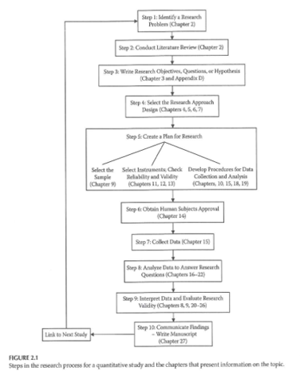

## Step 1: Identify a research problem

- Chapter 2 of Gliner et al
- Week 2 of this class

## Step 2: Conduct a literature review

- Chapter 2 of Gliner et al
- Various web resources
- Week 3 of this class

## Step 3: Write research objectives, questions, or hypotheses

- Chapter 3 of Gliner et al
- Week 2 of this class
- PICO format
- Research without a research hypothesis

## Step 4: Select the research approach

- Randomized experiments (Chapter 5, Week 4)
- Quasi experimental designs (Chapters 5, 6, Week 5)
- Observational designs (Chapter 7, Week 6)

## Step 6: Obtain ethical approval

- Chapter 14 of Gliner et al.
- Week 2 of this class.
- Think about ethical issues from the very start.

## Step 7: Collect your data

- Chapters 13, 15 of Gliner et al
- Week 10, 11

## Step 8: Analyze your data

- Chapters 16-22 of Gliner et al.
- Week 12, 13 of this class.

## Break #1

- What you have learned
  - Steps in research
- What’s coming next
  - Identify a research problem

## Identify a research problem

- Definitions are vague
  - What is a problem? question? aim? goal?
  - Sources of research problems
    - Read
    - Listen
    - Observe

## Characteristics of a good research problem

- More dichotomies
  - Broad vs Narrow
  - Widespread vs Limited interest
  - Well-researched vs Unknown territory

## Considerations in Choosing a Topic, 1 of 2

- Resources
  - Time
  - Cost
  - Support
  - Access
  - Control

## Considerations in Choosing a Topic, 2 of 2

- Interest and enthusiasm
- Scope of the problem
- Contribution to the profession
  - Adapted from Cottrell & McKenzie. *Health Promotion & Education Research Methods* . 2005.

## Do nots

- What should NOT drive picking a research question
  - A specific research methodology
  - A specific funding opportunity
  - A publication-focused motivation
    - But always publish your work.

## Break #2

- What you have learned
  - Identify a research problem
- What’s coming next
  - Developing a research hypothesis

## FINER criteria

- Feasible
- Interesting
- Novel
- Ethical
- Relevant
  - Source: Hulley, Cummings, Browner, Grady, Hearst, & Newman. *Designing Clinical Research* . 2001.

## Developing a research hypothesis

- Identify your research hypothesis early.
- Use the PICOTS framework.
  - P = patient
  - I = intervention
  - C = comparison
  - O = outcome
  - T = time frame
  - S = setting
- Your hypothesis may change as you delve deeper.

## Not all research needs a hypothesis.

- Examples
  - Estimation
  - Identification

## Three types of variables.

- Outcome variable(s)
- Independent variable(s)
  - Active
  - Attribute
- Covariates

## Three types of analyses

- Difference
  - A - B > 0
  - or ratio A/B > 1
- Associational
  - A and B are correlated
- Descriptive
  - Means, standard deviations, or proportions of A and B.
- These categories are not mutually exclusive.

## Schematic diagram of research approaches

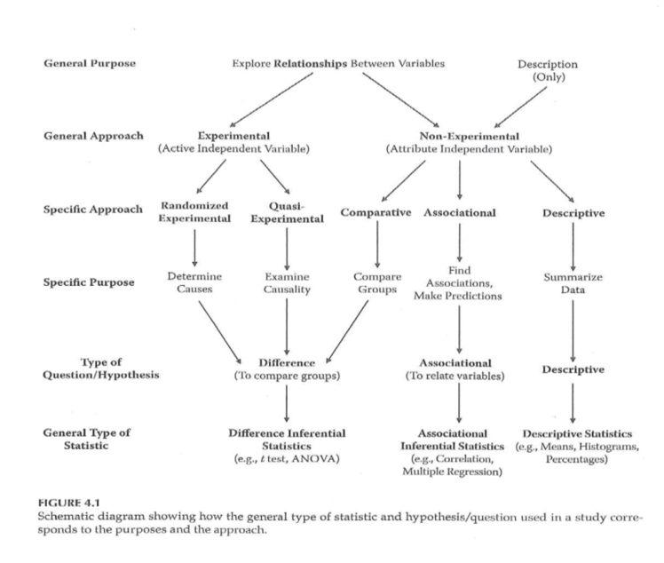

## Break #3

- What you have learned
  - Developing a research hypothesis
- What’s coming next
  - Historical overview of research ethics

## Landmarks in research ethics

- Nuremberg code (1947)
- Declaration of Helsinki (1964)
- Belmont report (1978)
- Title 45 of the Code of Federal Regulations, Part 46 (1981)
- Health Insurance Portability and Accountability Act (1996)

## Landmarks in research ethics

- Pure Food and Drugs Act (1906)
- Federal Food, Drug, and cosmetic Act (1938)
- Kefauver Harris amendments (1962)
- FDA Modernization Act (1997)
- Best Pharmaceuticals for Children Act (2002)

## Break #4

- What you have learned
  - Historical overview of research ethics
- What’s coming next
  - IRB approval

## Does my study need IRB approval

- Is it research?
  - Designed in advance
  - Systematic approach
  - Generalizable knowledge
  - Quality improvement versus research
- Does it involve human subjects?
  - interaction with a person, or
  - use of private information.
- Other minor exemption categories

## IRB categories of approval

- Exempt from review
- Expedited review
- Full review

## Break #5

- What you have learned
  - IRB approval
- What’s coming next
  - Ethical issues

## Ethical issues

- Conflict of interest
- Unfavorable risk/benefit ratio
- Loss of equipoise
- Deception
- Violating privacy

## Ethical concerns in animal studies

- Review by IACUC.
  - Mandated by Animal Welfare Act and USDA regulations
  - Live vertebrate animals
  - Sample size justification

## Research misconduct (other than fraud)

- Inappropriate authorship
  - Ghost writing
  - Leaving off deserving authors
  - “Honorary” authorship
- Violation of confidentiality
- Sabotage

## Whistle blowing

- Failure to report research misconduct is research misconduct
- No retaliation for legitimate complaints.

## Research Ethics

- NIH definition (NIH Catalyst, 2001)
  - Fabrication
    - inventing data or results
  - Falsification
    - manipulating research materials, equipment, or processes, or changing or omitting data or results
  - Plagiarism
    - appropriation of ideas, processes, results, or words of another person without giving appropriate credit

## Research Ethics

- Training
  - CITI training - used by multiple institutions
- IRBs
  - UMKC IRB
  - IRBs at other institutions (CMH, St. Luke’s)
- Research committees

## Summary

- What you have learned
  - Steps in research
  - Identify a research problem
  - Developing a research hypothesis
  - Historical overview of research ethics
  - IRB approval
  - Ethical issues